# Coursework Report

*N* removed NAs: 2

*N* removed typo: 1

*N* removed <18: 14

*N* total clean: 133

| Group | *N* | *M*<sub>age</sub> | *M*<sub>rating</sub> |
| --- | --- | --- | --- |
| Control | 68 | 20.59 | 5.73 |
| Experim | 65 | 20.45 | 6.98 |

**Main analysis results**

*t*(131) = -10.02, *p* < .001

[interactive chart not shown]

[figure not shown]

[interactive chart not shown]

# Coursework Report

Analysing Data, Spring 2020

# Methods

## Participants

Table 1

| Group | N | Mage | Sdage | Attractiveness |
| --- | --- | --- | --- | --- |
| control | 67 | 20.60 | 1.78 | 5.72 |
| experimental | 65 | 20.45 | 1.70 | 6.98 |

Table 1 represents the descriptive statistics of participants from both the control and experimental group.

Table 2

| Group | N | Mage | Mean_it1 | Mean_it2 | Mean_it3 | Attractiveness |
| --- | --- | --- | --- | --- | --- | --- |
| control | 67 | 20.60 | 6.10 | 5.52 | 5.54 | 5.72 |
| experimental | 65 | 20.45 | 7.11 | 6.86 | 6.98 | 6.98 |

Table 2 represents the descriptive statistics of participants from both the control and experimental groups, along with the separate mean scores given for each rated item.

## Design

It is hypothesised that photographed men in red coloured frames will be perceived as more attractive by women compared to photographed men in white coloured frames. The independent variable is the colour of the frames; the dependent variable is participants’ ratings of the pictures of men in terms of attractiveness. Participants from the control group were shown a white frame while participants from the experimental group were shown a red frame. Perceived attractiveness was assessed based on how attractive they thought the person was, how pleasant the person was to look at, and whether or not they would think the person was as attractive if they were to met in real life. Participants had to give a rating between 1 to 9; 1 indicating that the person was not at all attractive, 9 indicating that the person was extremely attractive. The higher rating received, the more attractive the person was perceived to be. A composite score will be calculated from the means of the three different questions on perceived attractiveness. An independent t-test will also be executed to check for a significant difference in results.

# Results

We performed an independent t-test to investigate how different coloured frames affected the attractiveness of the person in it. There were 67 participants in the control group and 65 participants in the experimental group. Results showed that participants from the experimental group (*M* = 6.98) scored higher in perceived attractiveness than the control group (*M* = 5.72) , with a signficiant mean difference (*M*<sub>diff</sub> = 1.26, 95% CI [-1.51, -1.01], *t* (130) = -10.05, *p* < .001 ).

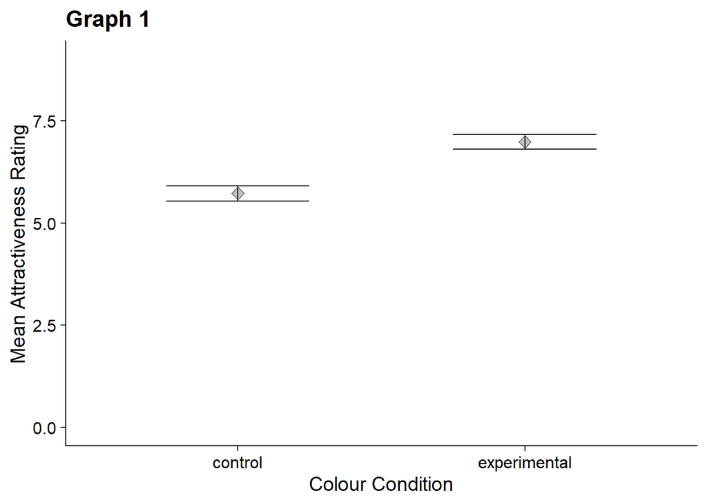

Graph 1 illustrates the mean attractiveness rating scores of participants from the control and experimental group with error bars.

# Discussion

The outcome of this investigation corresponds with the hypothesis of the original study done by Elliot et al. (2010). Based on the results of the attractiveness rating scores, photographed men in red coloured frames were perceived as more attractive by women compared to the photographed men in white coloured frames. This suggests that when we visually integrate the colour red with pictures of the same man, he is perceived to be more attractive.

Majority of the studies that examine the effects the colour red has on attractiveness have produced similar results as well, whereby men who were wearing or were associated with the colour red were perceived as more attractive or sexually desirable by the other gender. One example would be an experiment by Guéguen (2012) where photographed women in different coloured tees were shown to male participants. They judged that women in red looked more approachable and had higher sexual intents. On the other hand, there are also studies that claim the opposite. Hesslinger, Goldbach, and Carbon (2015) replicated two of the experiments done in the original study by Elliot et al. (2010). Contrary to the original study, they found no significant effect of the colour red in attraction, but they discovered that formal apparels were associated with higher attractiveness in women. For this reason, it remains unclear whether or not the colour red can confidently increase human attractiveness. Having said that, this could also be due to the slight alterations in the data collection process between the two experiments. Hesslinger and colleagues modified the test in a way that participants were in groups when writing down their rating scores, which could have potentially led to invalid results as participants may not answer the questions genuinely since they were liable to having their answers seen by their surrounding peers. They also used a variety of photographed men, which may once again lead to invalid results as the appearance of men may have influenced participants’ decisions instead of just the colour factor.

Nevertheless, there are several strengths to this study. The investigation we conducted were relatively similar to the original study in terms of methodology. Our results were also consistent with the original study, indicating that their experiment is replicable and reliable. Furthermore, multiple measures were used to obtain data. Perceived attractiveness is complex and difficult to measure, so a range of different questions that ultimately have the same interpretation were carefully designed. This can ensure that the final average of participants’ answers were based on their honest opinions rather than by chance. On the other hand, one concern about this study is the small sample size of 132 participants that may have decreased the generalisability. Generalisability is important in research as it indicates how an outcome of a study can also be applied to different types of people in the real world, most commonly to different genders, cultures, or ages. By having a small sample size in this experiment, the results may only apply to females who are above the age of 18. We decided to exclude participants who were below the age of 18 because their cognitive development and thought processes may differ from older individuals, hence influencing their rating scores. Another limitation of this study is participants’ personal colour preference that may have acted as a confounding variable. It would not come as a surprise that every individual has a favourite or preferred colour. Since we did not test this prior the experiment, we do not know if participants from the experimental group merely favoured the colour red over white, which led to the subsequent outcome, or that the photographed man in the red frame did in fact look more physically attractive. We decided not to question participants on their preferred colour as it may have led to demand characteristics. Revealing too much information about the objective of the experiment can result in participants altering their answers to coincide with the expectations of the research. Taking into account the strengths and limitations of this study, we conclude that the colour red can increase the attractiveness of a man, but only under particular circumstances.

Accordingly, future studies can conduct further investigations by collecting rating scores from men instead. This way, we can obtain more evidence on the overall impact of the colour red on attractiveness, and not just in females. Performing a similar experiment with children by amending certain measures would also be an interesting contribution to this field of study. For example, researchers can investigate whether children gravitate more towards red or other coloured toys and determine if the colour red can increase attractiveness in all aspects, or if it is only relevant in the context of sexual attractiveness. Moreover, future experiments can also replicate this study and emphasise the reasons behind participants’ answers. A possible approach would be adding on follow-up questions on why they did or did not choose a certain colour. Consequently, we can gather more knowledge on how colours affect decision-making, as well as identify any possible patterns in reasoning.

As a conclusion, our findings strengthen the theory that men who are associated with the colour red are perceived by women as more attractive than if they were associated with the colour white. However, insufficient evidence on the underlying connotations of the colour red have been yielded due to its complexity and vagueness. Regardless, colour is a basic characteristic of visual perception that is present everywhere while unconsciously influencing our decisions and outlook on life.

# References

Elliot, A. J., Niesta Kayser, D., Greitemeyer, T., Lichtenfeld, S., Gramzow, R. H., Maier, M. A., & Liu, H. (2010). Red, rank, and romance in women viewing men. *Journal of Experimental Psychology: General, 139*(3), 399.

Guéguen, N. (2012). Color and women hitchhikers’ attractiveness: Gentlemen drivers prefer red. *Color Research & Application*, 37(1), 76-78.

Hesslinger, V. M., Goldbach, L., & Carbon, C. C. (2015). Men in red: A reexamination of the red-attractiveness effect. *Psychonomic bulletin & review, 22*(4), 1142-1148.